# Ciencia de datos. Parte 08: Informes automatizados con R-markdown

6 de febrero de 2016

## Markdown

- Markdown es un lenguaje de marcado (como HTML o LaTeX)
- Permite editar documentos en formato HTML, PDF y Word.
- Estos lenguajes suelen estar pensados para máquinas.
- El codigo fuente de Markdown es fácil de leer.
- Es un formato cada vez más popular entre periodistas…

## Aprendiendo Markdown:

- Markdown se aprende en unos minutos.
- Ayuda en https://help.github.com/articles/markdown-basics/
- Se puede generar un documento que tenga varias secciones, subsecciones, …
- texto en **negritas**
- texto en *cursiva*
- …

## R-Markdown

R-Markdown es una extensión de Markdown

- Permite mezclar código en R con documentos Markdown.
- El código aparece en "chunks":

```r
summary(cars)
```

```
##      speed           dist
##  Min.   : 4.0   Min.   :  2.00
##  1st Qu.:12.0   1st Qu.: 26.00
##  Median :15.0   Median : 36.00
##  Mean   :15.4   Mean   : 42.98
##  3rd Qu.:19.0   3rd Qu.: 56.00
##  Max.   :25.0   Max.   :120.00
```

## Edición y compilación

Para crear y compilar un documento R-Markdow:

- Abre un nuevo documento de tipo Rmd (File > R Markdown)
- Elimina lo que te sobra en la plantilla y comienza a editar…
- Pulsa el botón **Knit** (HTML/PDF/DOC) de la parte superior para compilarlo.

## Pequeña demostración

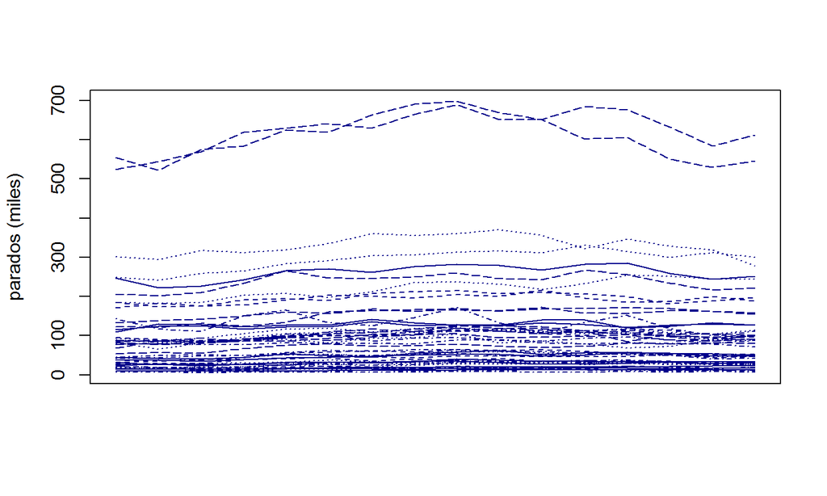

```r
require(data.table)
paro <- fread("data/paro.csv")
tmp <- dcast(paro,Situation+Periodo~Provinces,fun=sum)
parados=subset(tmp,Situation=="Unemployed persons")
matplot(parados,type="l",ylab="parados (miles)",col="blue4",xaxt='n')
```

## Practicando R-Markdown

1. Crea un documento RMarkdown (File > R Markdown)
- Edita el contenido de la plantilla.
- Crea nuevos "chunks" que hagan cosas.
1. Utiliza R Markdown
- Para crear un informe relativo a tu trabajo.
- Alternativamente, para "pasar a limpio" las notas anteriores.
1. Investiga
- Cómo usar CSS para cambiar el formato por defecto.
- La mejor manera de insertar tablas en documentos.